# Explicit Interaction Community Models

Miguel Porto, Pedro Beja[^1]

# Getting started with EICMs

## The model

EICMs are an extension of binomial Generalized Linear Models for joint modelling of species communities, that incorporate both the effects of species biotic interactions and the effects of missing covariates. The model is a system of simultaneous equations, where species interactions are modelled explicitly as direct effects of each species on each of the others, and are estimated alongside the effects of missing covariates, modelled as latent factors. The `eicm` package includes a Penalized Maximum Likelihood fitting function, and a Genetic Algorithm for selecting the most parsimonious species interaction network topology. There are methods for computing confidence intervals and for plotting results.

## Basic fitting workflow

### Select interaction network topology

Fitting and selecting the species interaction network topology is pretty simple. Assuming all you have is a presence/absence data matrix in `occurrences`, you just have to run (assuming you trust the defaults):

```r
# fit & select an EICM with 2 latent variables
m <- eicm(occurrences, n.latent=2)

# display estimated coefficients (note they are organized in matrices)
coef(m$selected.model)
```

This will end up with a model where the species interaction network topology has been selected in respect to a parsimony criterion, and the respective coefficients have been estimated. We started with the most complex (and realistic) scenario:

- all environmental predictors are unmeasured, so we should/must estimate latent variables;
- we don’t have clues of possible species interactions, so we assume all interactions are possible (the default).

If, however, you need more control on model hyperparameters (and you will need), these are the most important arguments to define:

```r
m <- eicm(occurrences, n.latent=2, regularization=c(6, 0.5), penalty=4, theta.threshold=0.5)
```

Some explanation on the arguments (but see `?eicm`):

- `occurrences`: the occurrence data matrix (binary, for the time being)
- `n.latent`: how many latent variables we want to estimate
- `regularization`: the ridge regularization lambdas for penalized ML fitting. The first element applies to environmental coefficients and latents, the second element to species interaction coefficients
- `penalty`: the penalty applied to the number of species interactions to include (multiplier), during network selection
- `theta.threshold`: the threshold to exclude species interactions *a priori*. Species interactions whose preliminary coefficient (in absolute value) is lower than `theta.threshold` are excluded from the network selection stage

Note that, by default, this function will run in all available CPU cores, which greatly speeds up the network selection stage. Set `n.cores`, if otherwise desired.

### Excluding unlikely interactions

#### Formula syntax

```r
# excluding interactions with the formula syntax
m <- eicm(occurrences, forbidden=list(
    sp3 ~ sp4 + sp5,        # sp3 must not be affected by sp4 nor sp5
    sp4 ~ .,                # sp4 must not be affected by any other
    sp1 ~ . - sp8           # sp1 must not be affected by any other except sp8
    ))

# display species interaction coefficients
# note the zeroed coefficients are those that were excluded
coef(m$fitted.model)$sp
```

#### Matrix syntax

The non-zero elements of the square binary species x species matrix are read as follows: species A (column) affects species B (row).

```r
# Excluding interactions with the matrix syntax

# create a square matrix species x species, all zeroes
mask <- matrix(0, nrow=ncol(occurrences), ncol=ncol(occurrences))

# set to 1 those interactions we want to include
mask[4, 2] <- 1     # species #2 may affect species #4
mask[6, 1] <- 1     # species #1 may affect species #6
mask[, 7] <- 1      # species #7 may affect any other
mask[2, ] <- 1      # species #2 may be affected by any other

m <- eicm(occurrences, mask.sp=mask)

# display species interaction coefficients
# note the zeroed coefficients are those that were excluded
coef(m$fitted.model)$sp
```

You can also easily exclude interactions which depart from rare species, because they will be very difficult to detect anyway, so excluding them from the start may compensate the risk. Note that this does not exclude the possibility that the rare species are affected by others, only that rare species do not affect others.

```r
# exclude interactions departing from species with 20 or less occurrences
m <- eicm(occurrences, mask.sp=mask, exclude.prevalence=20)
```

### Fitting without selecting network

If you have already a predefined interaction network topology and only want to estimate the respective coefficients, you may skip the selection stage (which is the most time-consuming task). We illustrate this with 2 latent variables:

```r
# Load the included true model (32 species, 30 interactions, 2 environmental predictors)
data(truemodel)

# realize the model
occurrences <- predict(truemodel, nrepetitions=1)

# Pre-define a network topology
# For illustrative purposes, let's assume we know the true network topology so we build
#  the mask from the true model coefficients:
# 0: don't estimate interaction
# 1: estimate interaction
mask <- ifelse(truemodel$model$sp == 0, 0, 1)

# And now we estimate their values
# here we discard all the predictors - note that we don't provide any predictor matrix,
# only the presence/absence data.
m <- eicm(occurrences, n.latent=2, mask.sp=mask, do.selection=FALSE,
    regularization=c(1, 0.1))
```

-> running time of the above code chunk: 1.3 minutes

We can readily plot the estimated species interaction network.

```r
# Plot estimated species interaction network
plot(m, type="network")
```

[output not shown]

The package also provides a plotting function that allows to visually compare the estimated model coefficients and network topology with those of the true model, when data is simulated.

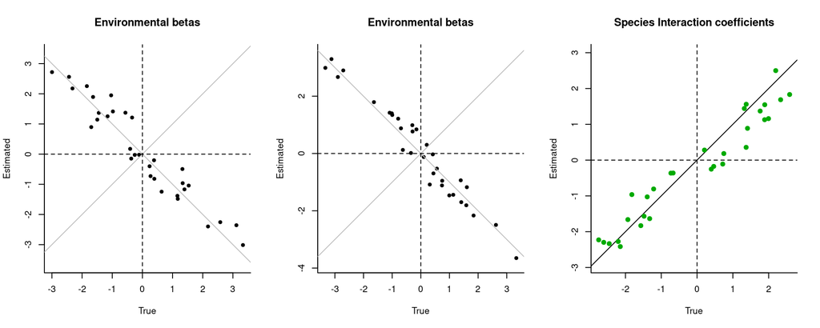

Estimated versus true coefficients of a fitted EICM model over simulated data, with the true environmental predictors dropped, and estimated as latent variables.

```r
# Plot the network topology comparison between true and estimated models
# (plot omitted from vignette)
plot(m, true.model=truemodel, type="network")

# Plot estimated versus true coefficients
# Note that the environmental coefficients here relate to estimated latent variables,
# not the true predictors.
plot(m, true.model=truemodel, nenv.to.plot=2, legend=FALSE)
```

```r
# display estimated species interaction coefficients (head only)
# the zeroed coefficients are those that were excluded a priori
head(round(coef(m$fitted.model)$sp, 3))
```

```
##       sp001 sp002 sp003 sp004 sp005 sp006 sp007 sp008 sp009 sp010  sp011 sp012
## sp001     0     0     0     0     0     0     0     0     0     0  0.000     0
## sp002     0     0     0     0     0     0     0     0     0     0  0.000     0
## sp003     0     0     0     0     0     0     0     0     0     0  0.000     0
## sp004     0     0     0     0     0     0     0     0     0     0 -2.274     0
## sp005     0     0     0     0     0     0     0     0     0     0  0.000     0
## sp006     0     0     0     0     0     0     0     0     0     0  0.000     0
##       sp013 sp014 sp015 sp016 sp017 sp018 sp019 sp020 sp021 sp022 sp023 sp024
## sp001     0     0     0     0     0     0     0 1.687     0     0     0     0
## sp002     0     0     0     0     0     0     0 0.000     0     0     0     0
## sp003     0     0     0     0     0     0     0 0.000     0     0     0     0
## sp004     0     0     0     0     0     0     0 0.000     0     0     0     0
## sp005     0     0     0     0     0     0     0 0.000     0     0     0     0
## sp006     0     0     0     0     0     0     0 0.000     0     0     0     0
##       sp025 sp026  sp027 sp028 sp029 sp030  sp031 sp032
## sp001 0.000     0  0.000     0     0     0  0.000     0
## sp002 1.833     0 -0.176     0     0     0  0.000     0
## sp003 0.000     0  0.000     0     0     0  0.000     0
## sp004 0.000     0  0.000     0     0     0 -1.661     0
## sp005 0.000     0  0.000     0     0     0  0.000     0
## sp006 0.000     0  0.000     0     0     0  0.000     0
```